## What you should submit

The goal of your project is to predict the manner in which they did the exercise. This is the “classe” variable in the training set. You may use any of the other variables to predict with. You should create a report describing how you built your model, how you used cross validation, what you think the expected out of sample error is, and why you made the choices you did. You will also use your prediction model to predict 20 different test cases.

### Peer Review Portion

Your submission for the Peer Review portion should consist of a link to a Github repo with your R markdown and compiled HTML file describing your analysis. Please constrain the text of the writeup to < 2000 words and the number of figures to be less than 5. It will make it easier for the graders if you submit a repo with a gh-pages branch so the HTML page can be viewed online (and you always want to make it easy on graders :-).

### Course Project Prediction Quiz Portion

Apply your machine learning algorithm to the 20 test cases available in the test data above and submit your predictions in appropriate format to the Course Project Prediction Quiz for automated grading.

### Reproducibility

Due to security concerns with the exchange of R code, your code will not be run during the evaluation by your classmates. Please be sure that if they download the repo, they will be able to view the compiled HTML version of your analysis.

## Common error measures

1. Mean squared error (or root mean squared error)
- Continuous data, sensitive to outliers
2. Median absolute deviation
- Continuous data, often more robust
3. Sensitivity (recall)
- If you want few missed positives
4. Specificity
- If you want few negatives called positives
5. Accuracy
- Weights false positives/negatives equally
6. Concordance
- One example is kappa
5. Predictive value of a positive (precision)
- When you are screeing and prevelance is low

[figure not shown]

[figure not shown]

[output not shown]

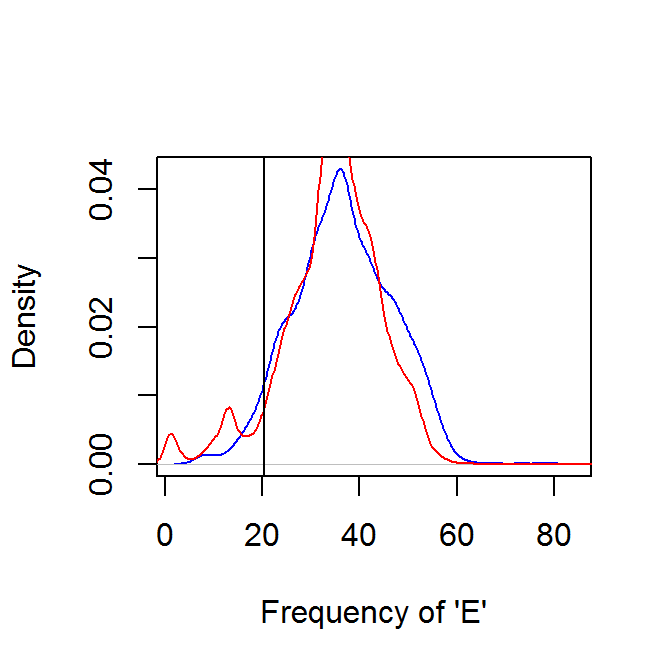

```r
plot(density(tran$total_accel_forearm[tran$classe=="E"]),
     col="blue",main="",xlab="Frequency of 'E'")
lines(density(tran$total_accel_forearm[!tran$classe=="E"]),col="red")
abline(v=20.5,col="black")
```

```r
prediction <- ifelse(tran$total_accel_forearm > 20.5,"E","A")
table(prediction,tran$classe)/length(tran$classe)
```

```
##
## prediction           A           B           C           D           E
##          A 0.035980022 0.015187035 0.011211905 0.004433799 0.009377230
##          E 0.248394659 0.178320253 0.163184181 0.159463867 0.174447049
```

```r
library(kernlab); data(spam); set.seed(333)
```

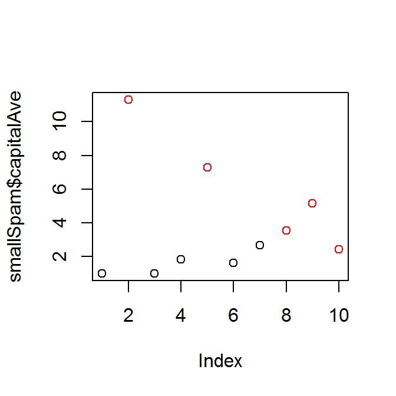

```r
smallSpam <- spam[sample(dim(spam)[1],size=10),]
spamLabel <- (smallSpam$type=="spam")*1 + 1
plot(smallSpam$capitalAve,col=spamLabel)
```

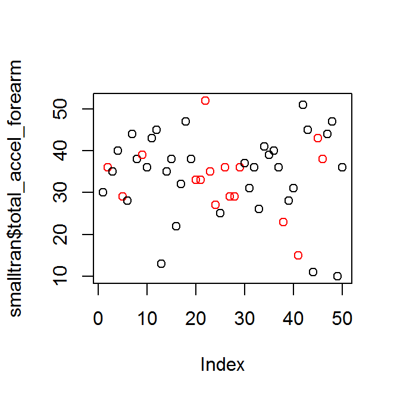

```r
set.seed(333)
smalltran <- tran[sample(dim(tran)[1],size=50),]
tranLabel <- (smalltran$classe=="A")*1 + 1
plot(smalltran$total_accel_forearm,col=tranLabel)
```

```r
rule1 <- function(x){
  prediction <- rep(NA,length(x))
  prediction[x > 2.7] <- "spam"
  prediction[x < 2.40] <- "nonspam"
  prediction[(x >= 2.40 & x <= 2.45)] <- "spam"
  prediction[(x > 2.45 & x <= 2.70)] <- "nonspam"
  return(prediction)
}
table(rule1(smallSpam$capitalAve),smallSpam$type)
```

```
##
##           nonspam spam
##   nonspam       5    0
##   spam          0    5
```

```r
rule1 <- function(x){
  prediction <- rep(NA,length(x))
  prediction[(x >= 29 & x <= 43)] <- "A"
  return(prediction)
}
table(rule1(smalltran$total_accel_forearm),smalltran$classe)
```

```
##
##      A  B  C  D  E
##   A 12  8  5  2  4
```